# Analyzing SARS-CoV-2 in Pennsylvania Wastewater Samples

# Figures

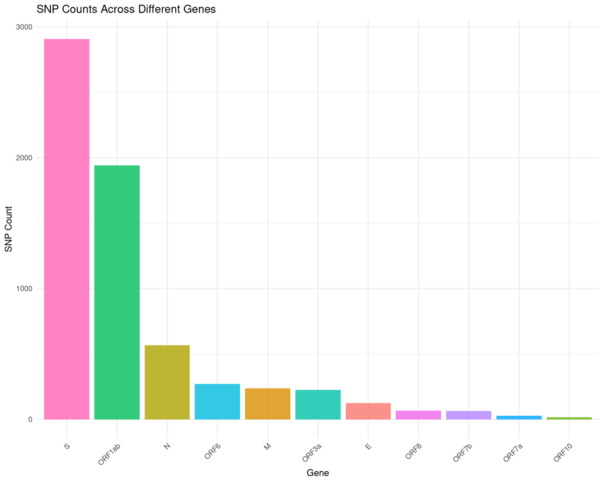

**Figure 1**: Bar plot showing the number of single nucleotide polymorphisms (SNPs) identified across different genes of SARS-CoV-2. The genes are labeled on the x-axis, and the y-axis indicates the count of SNPs.

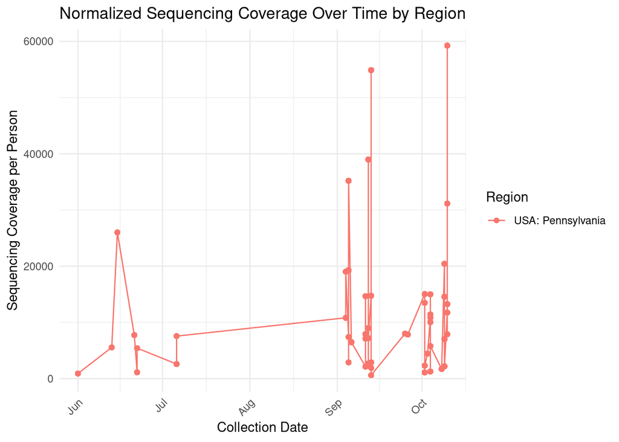

**Figure 2**:Temporal Trends in Normalized Sequencing Coverage Over Time in Pennsylvania The plot shows normalized sequencing coverage (SARS-CoV-2 RNA levels per person) over time for wastewater samples collected in Pennsylvania.

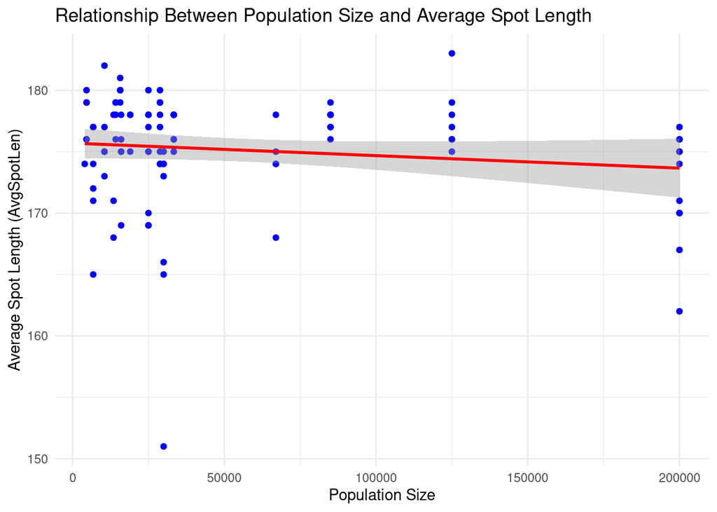

**Figure 4**: Scatter plot showing the relationship between population size and average spot length of sequencing reads. Each blue point represents a sample, and the red regression line indicates the overall trend.

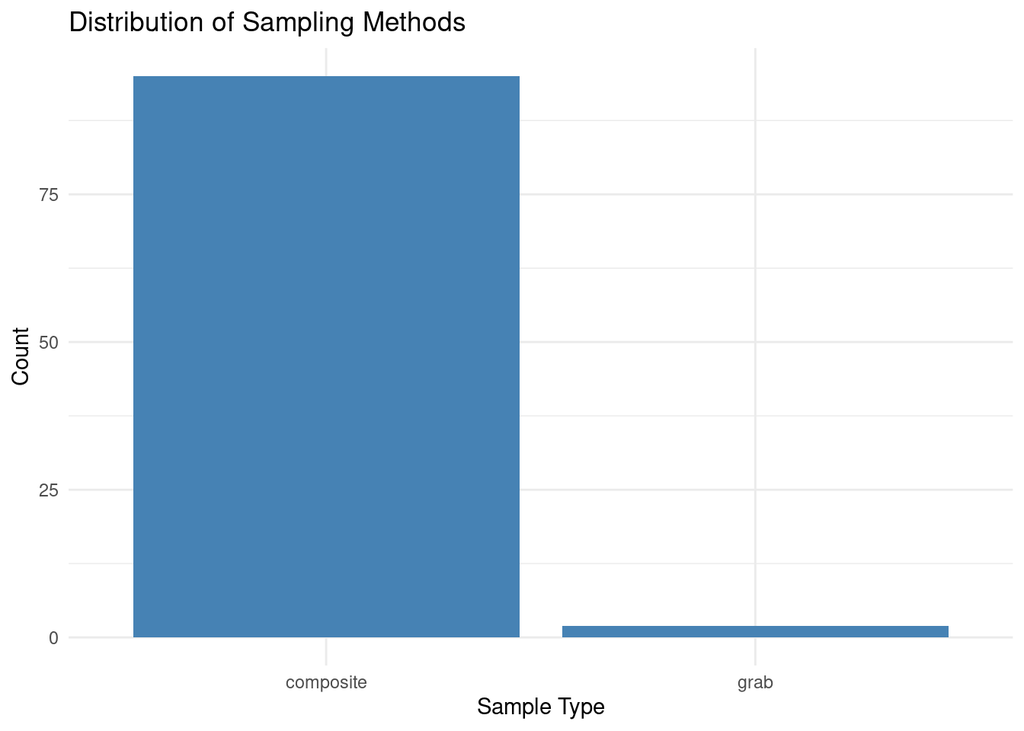

**Figure 5**: Bar plot showing the distribution of sampling methods. The majority of samples were collected using composite sampling, while grab sampling was used much less frequently.

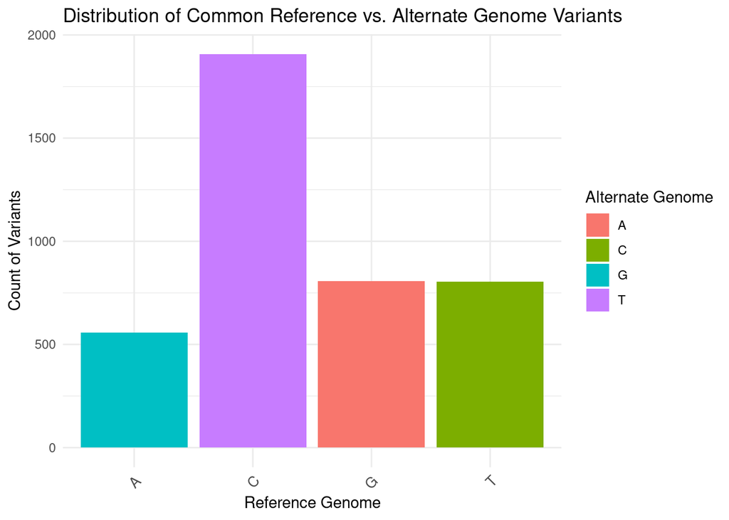

**Figure 6**: Distribution of Common Reference vs. Alternate Genome Variants. This bar plot displays the counts of variants classified by their reference genome nucleotide and corresponding alternate genome variants. Variants are categorized as A, C, G, and T based on their alternate genome.

# Tables

**Table 1**:Summary of Sequencing Coverage Metrics by Sampling Method.This table presents key statistics such as mean, median, minimum, and maximum coverage—stratified by sample type (composite vs. grab) and sample matrix (e.g., raw wastewater, post-grit removal).

Summary of Sequencing Coverage by Sampling Method

[output not shown]

# Sources Cited

Arnold,J.B. (2022) Ggthemes: Extra themes, scales and geoms for ’ggplot2’.

Bache,S.M. and Wickham,H. (2023) Magrittr: A forward-pipe operator for r.

Carrat,F. *et al.* (2022) Seroprevalence of sars-cov-2 in france by july 2021: Results from the second nationwide epicov survey. *PLOS Medicine*, **19**, e1003896.

Health Bureau of Laboratories Submission Group,P.D. of (2023) Sequencing of sars-cov-2 rna from wastewater influent samples collected in pennsylvania for genomic surveillance.

Kmush,B.L. *et al.* (2022) Comparability of 24-hour composite and grab samples for detection of sars-cov-2 rna in wastewater. *FEMS Microbes*, **3**, 1–5.

Knaus,B.J. and others (2023) VcfR: Manipulate and visualize vcf data.

Larsen,D.A. *et al.* (2022) Wastewater surveillance for sars-cov-2 rna in denmark, 2020–2021. *Environmental Health Perspectives*, **130**, 065001.

Neuwirth,E. (2023) RColorBrewer: ColorBrewer palettes.

OpenAI (2024) ChatGPT: Advanced ai language model.

Peccia,J. *et al.* (2022) Measurement of sars-cov-2 rna in wastewater tracks community infection dynamics. *Nature Biotechnology*, **40**, 181–186.

Pennsylvania Department of Health (2024) Pennsylvania wastewater surveillance system (pawss).

Surveillance of infectious disease through wastewater sequencing: Detect sars-cov-2 variants and other respiratory viruses in the community (2024) Illumina.

Wickham,H. (2016) Ggplot2: Elegant graphics for data analysis Springer-Verlag New York.

Wickham,H. *et al.* (2023) Dplyr: A grammar of data manipulation.

Wickham,H. and others (2023a) Testthat: Unit testing for r.

Wickham,H. and others (2023b) Tidyverse: Easily install and load the ’tidyverse’.

Xie,Y. (2023) Knitr: A general-purpose package for dynamic report generation in r.

Xie,Y. and others (2023) Rmarkdown: Dynamic documents for r.